# NBA Salaries exploration

John Yuill

2020-05-24

## Exploring descriptive stats on NBA salaries

### Overall NBA

**Summarize key fields**

```
##      salary           season_end    season_start
##  Min.   :    2706   Min.   :1985   Min.   :1984
##  1st Qu.:  630000   1st Qu.:1996   1st Qu.:1995
##  Median : 1500000   Median :2004   Median :2003
##  Mean   : 3164870   Mean   :2004   Mean   :2003
##  3rd Qu.: 3884239   3rd Qu.:2012   3rd Qu.:2011
##  Max.   :34682550   Max.   :2018   Max.   :2017
```

#### What are overall trends in average salary?

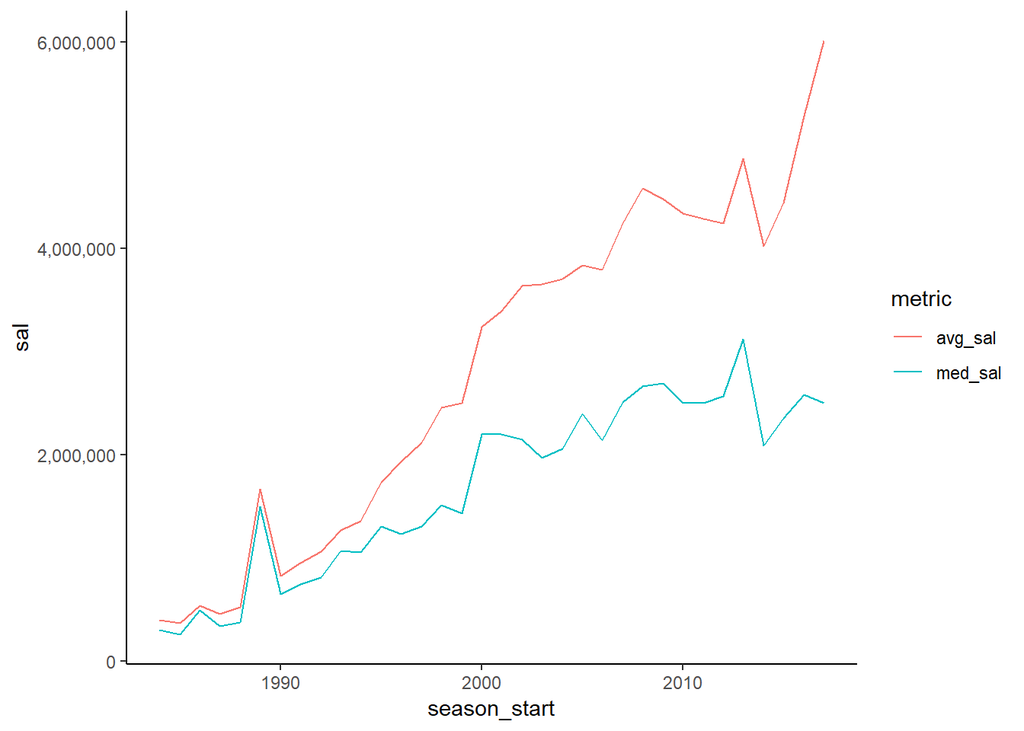

#### What does the distribution look like over the years?

**Boxplot view**

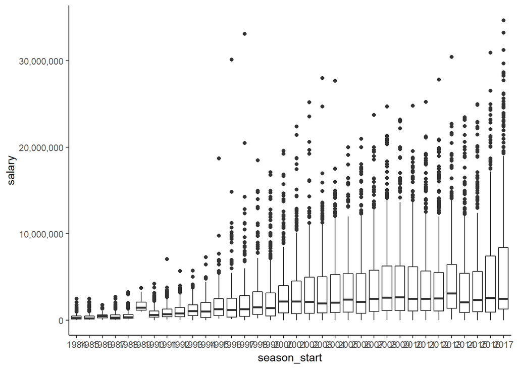

Layer in average salary for each year, along with 1 std dev above and 1 std dev below average, so to see how interquartile range compares over time. (for normal distribution, would be stable relationship)

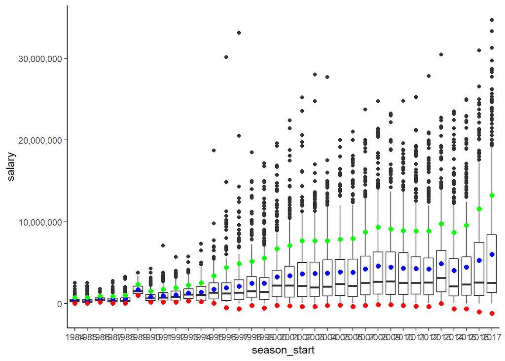

As the upper end of the salary range stretches over time, it pulls the average away from the median and widens the sd range so that it is not as useful a representation of spread in the data than IQR. At the same time, IQR is getting distorted by the upward pull of salaries. However, it accomodates this by adjusting the upper and lower bounds of the 50% in the middle, so that upper is farther above median than lower is below. Std dev is always balanced on either side of average.

**Histogram view**

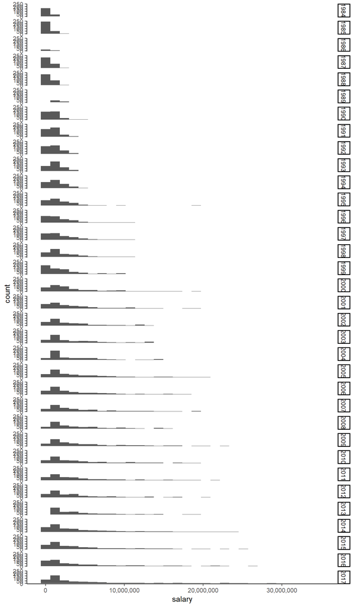

Too many years to deal with. How about group into 5 yrs.

**Better view when grouped over 5 yrs.**

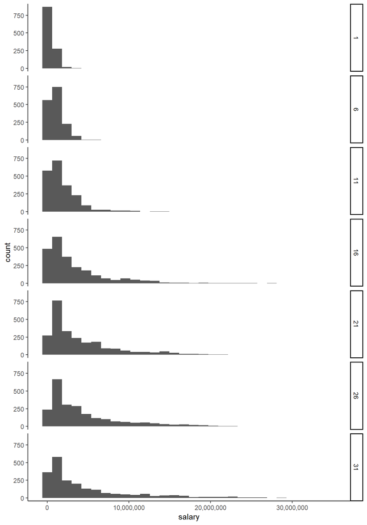

As shown with boxplot, the center shifts up a little over the years - maybe not that much different from inflation - but the tail gets stretched longer over time.

### Scottie Pippin

Scottie Pippin is considered to have established himself as one of the all-time greats while at Chicago Bulls in the 1990’s. At the same time, reported to have relatively low salary.

#### Career

The data I’ using has player names as ‘player_id’. Luckily, his is easy to find.

```
## # A tibble: 17 x 4
##    player_id   salary season  team
##    <chr>        <dbl> <chr>   <chr>
##  1 pippesc01   725000 1987-88 Chicago Bulls
##  2 pippesc01   575000 1988-89 Chicago Bulls
##  3 pippesc01   765000 1990-91 Chicago Bulls
##  4 pippesc01  2770000 1991-92 Chicago Bulls
##  5 pippesc01  3425000 1992-93 Chicago Bulls
##  6 pippesc01  3075000 1993-94 Chicago Bulls
##  7 pippesc01  2225000 1994-95 Chicago Bulls
##  8 pippesc01  2925000 1995-96 Chicago Bulls
##  9 pippesc01  2250000 1996-97 Chicago Bulls
## 10 pippesc01  2775000 1997-98 Chicago Bulls
## 11 pippesc01 11000000 1998-99 Houston Rockets
## 12 pippesc01 14795642 1999-00 Portland Trail Blazers
## 13 pippesc01 13750000 2000-01 Portland Trail Blazers
## 14 pippesc01 18083564 2001-02 Portland Trail Blazers
## 15 pippesc01 19727524 2002-03 Portland Trail Blazers
## 16 pippesc01  4917000 2003-04 Chicago Bulls
## 17 pippesc01  5408700 2004-05 Chicago Bulls
```

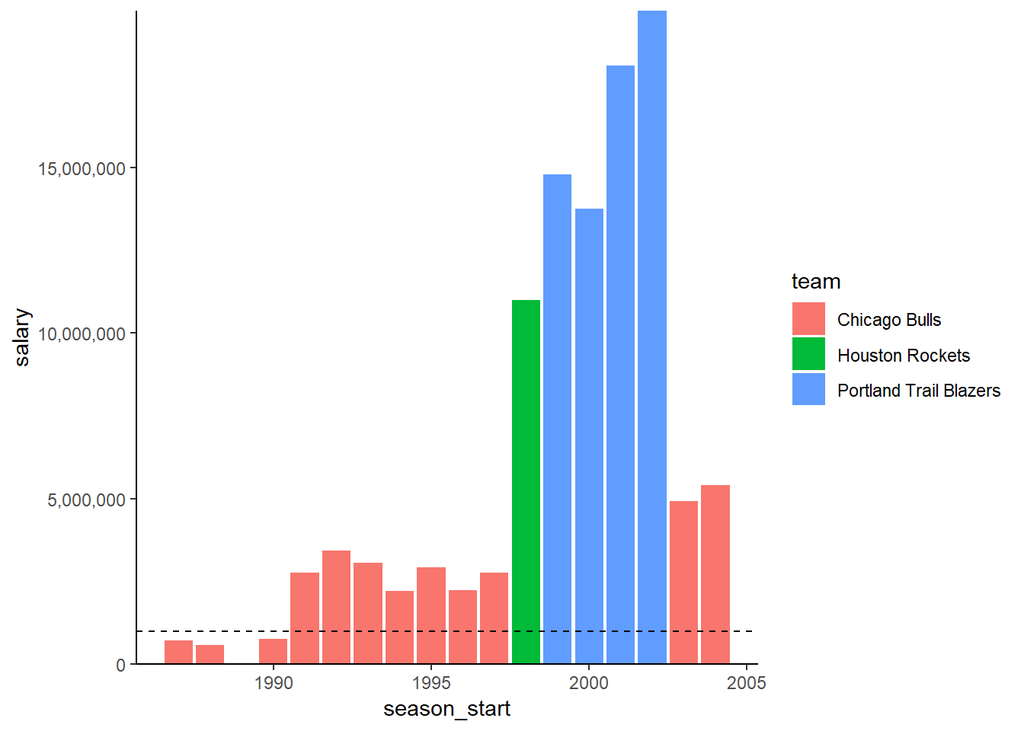

(dotted line = $1M)

Looks like even in early years with the Bulls, his salary varied. Although pushing $1M and then jumping well above it.

#### Where does he rank in the league each year?

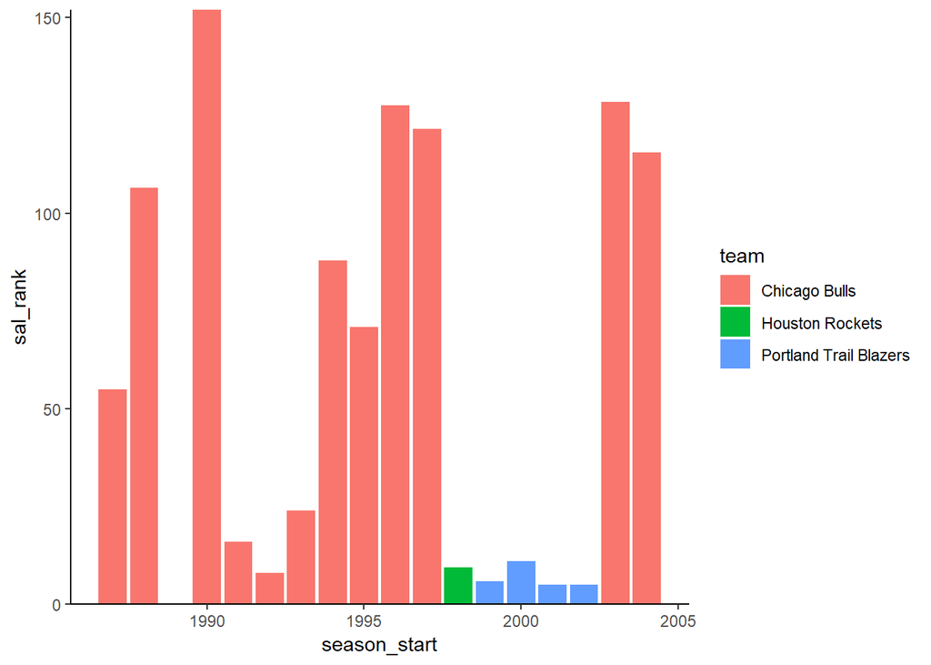

Varies wildly from year to year, with early years getting progressively bad, then rectified for 1991-1993, but started slipping again, until late 1990s. Houston Rockets and especially Portland Trail Blazers were much better to Scottie than the Bulls!

How does he compare to Jordan, say in 1990?

```
## # A tibble: 3 x 5
##   player_id  salary season  team            sal_rank
##   <chr>       <dbl> <chr>   <chr>              <dbl>
## 1 ewingpa01 4250000 1990-91 New York Knicks      1
## 2 jordami01 2500000 1990-91 Chicago Bulls        8.5
## 3 pippesc01  765000 1990-91 Chicago Bulls      152
```

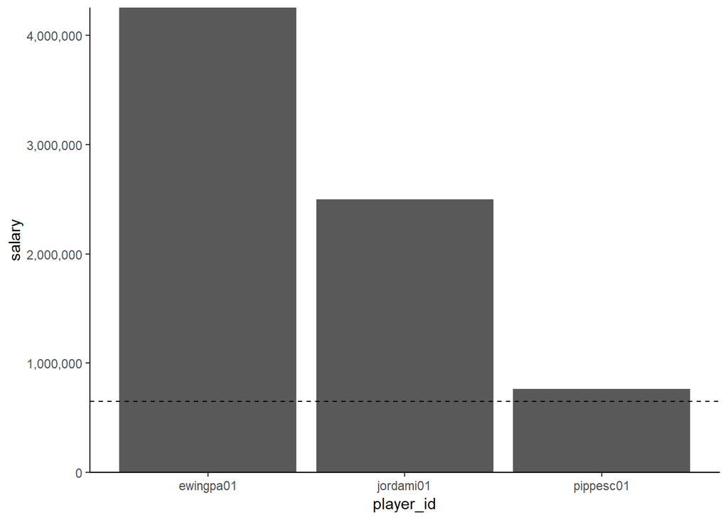

#### Where does he rank percentile-wise?

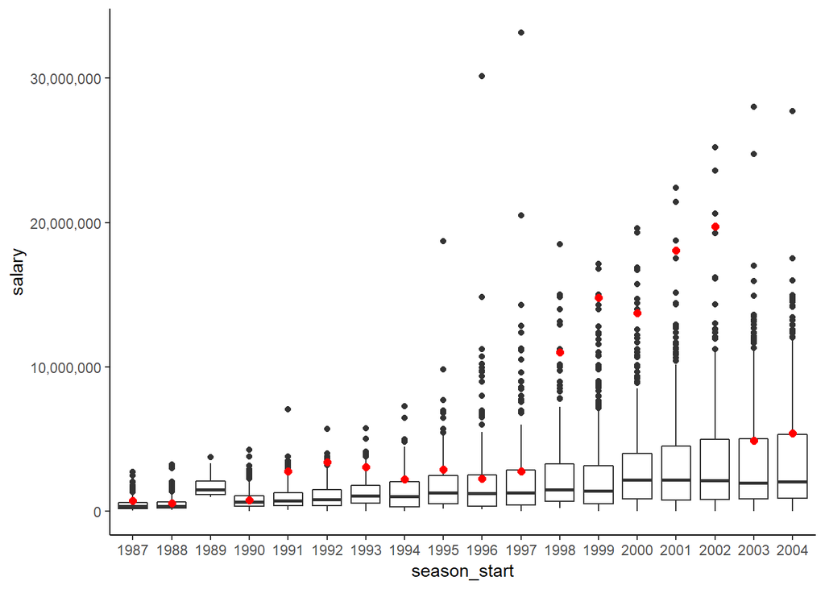

**How does he compare to Jordan?**